# Call Analysis

Jeffrey Waring

April 14, 2017

## Who calls me more: Jen or Kris?

Time to answer this important question: does my wife call me more or Kris? To answer, I logged all incoming calls for 18 months, using [this recipe from IFTTT](https://ifttt.com/applets/161618p-automatically-log-every-call-you-make-on-your-android-phone-to-a-google-spreadsheet).

First, I downloaded the .csv file, and added a header and slightly modified the date stamp column. Two subsets are created: one for Kris’ calls, and one for Jenny’s. Both subsets have a date object column created by concatenating monthh,day, and year factors previously read in.

```r
setwd("C:/Users/Jeffrey.Waring/R projects/Call logging")
df <- read.csv("Calls.csv",header=TRUE)

kris <- df[df$Caller=="Kris Larsen",]

#Now create a date column
kris$Date<-as.Date(paste(as.character(kris$Month),as.character(kris$Day),' ',as.character(kris$Year)),format="%B %d,%Y")
#and a weekday column
kris$Weekday<-c("Sunday", "Monday", "Tuesday", "Wednesday", "Thursday",
  "Friday", "Saturday")[as.POSIXlt(kris$Date)$wday + 1]

jenny <- df[df$Caller=="Jenny",]
#Now create a date column
jenny$Date<-as.Date(paste(as.character(jenny$Month),as.character(jenny$Day),' ',as.character(jenny$Year)),format="%B %d,%Y")
#and a weekday column
jenny$Weekday<-c("Sunday", "Monday", "Tuesday", "Wednesday", "Thursday",
                "Friday", "Saturday")[as.POSIXlt(jenny$Date)$wday + 1]
```

In total, I recieved: 192 calls from the dates:

```
## [1] "2014-05-22" "2015-11-20"
```

39.1% were from unknown numbers

These unknown numbers are excluded from further analysis.

## Now, some analysis

Clearly Kris is the winner for total calls:

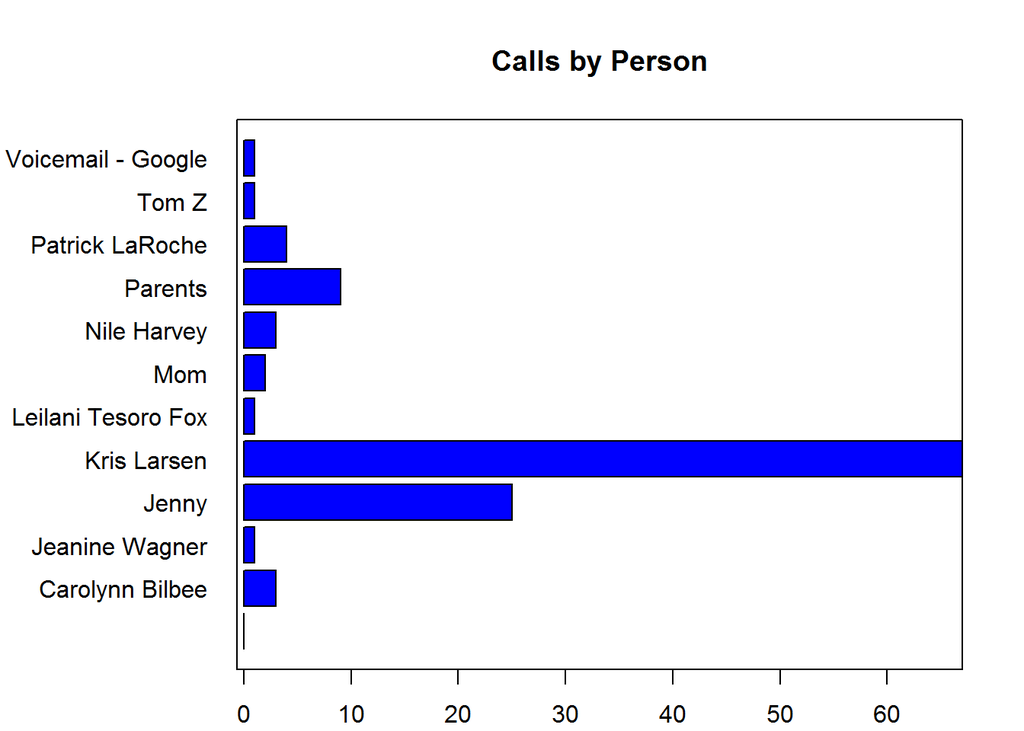

```r
par(mar = c(2, 8, 4, 2) + 0.1, mgp = c(4, 1, 0), las = 2)
barplot(table(df2$Caller),horiz=TRUE,col="blue",main="Calls by Person",xlab="# of calls",las=1)

box()
```

With a given average calltime of 83.6 seconds, Kris’ calls are also longer than average (77.3 seconds) and Jens’ (52.4 seconds):

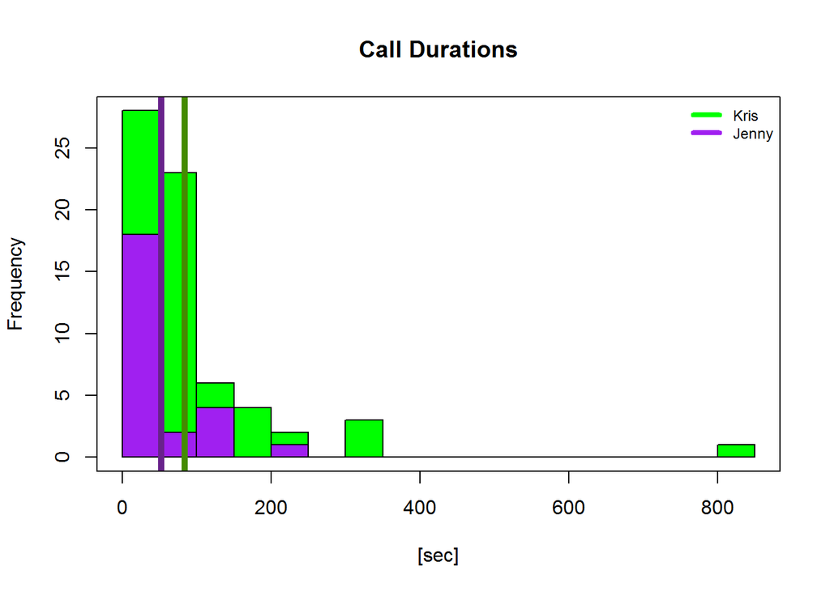

```r
hist(kris$length,col="green",breaks = 20,main="Call Durations",xlab="[sec]")
hist(jenny$length,col="purple",add=TRUE,breaks=5)
abline(v=mean(kris$length),col="chartreuse4",lwd=5)
abline(v=mean(jenny$length),col="darkorchid4",lwd=5)
legend('topright', c("Kris","Jenny"),lty=1, lwd=4,bty='n', cex=.75,col=c("green","purple"))
box()
```

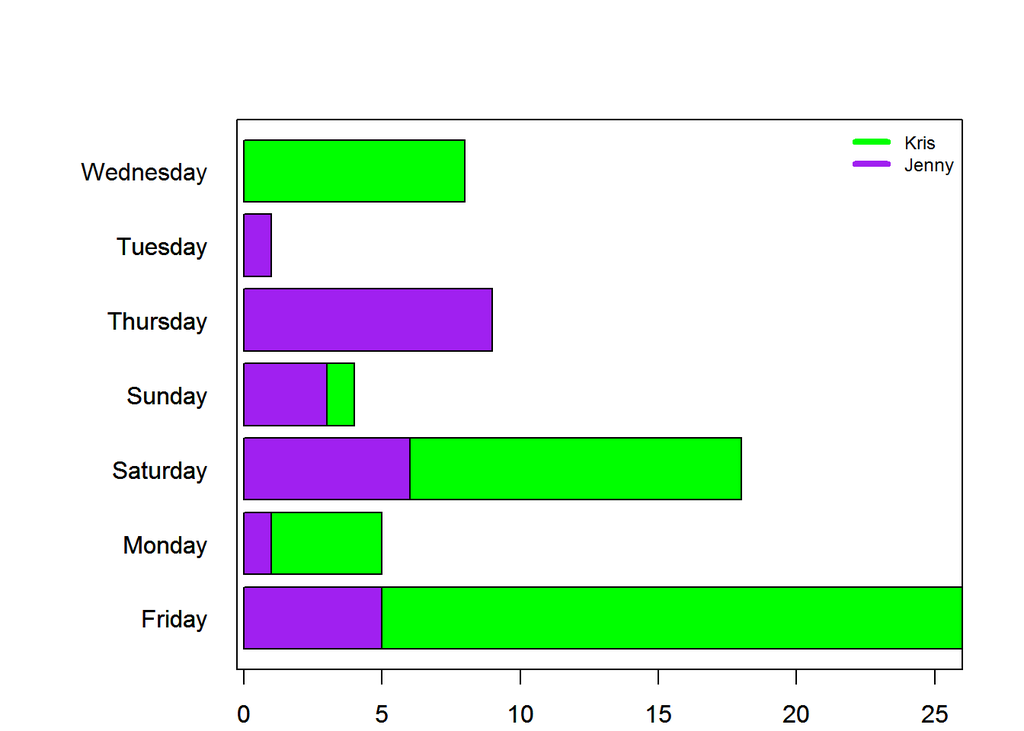

```r
par(mar = c(2, 8, 4, 2) + 0.1, mgp = c(4, 1, 0), las = 2)
barplot(table(kris$Weekday),las=1,hori=TRUE,col="green")
barplot(table(jenny$Weekday),las=1,hori=TRUE,col="purple",add=TRUE,xlab="# of calls")
legend('topright', c("Kris","Jenny"),lty=1, lwd=4,bty='n', cex=.75,col=c("green","purple"))
box()
```